# TCGA Data Analysis

# Installing the ICeDT library

```r
library(devtools)
install_github("Sun-lab/ICeDT")
```

# Load required library

```r
library(data.table)
library(R.utils)
library(ICeDT)
library(ggcorrplot)
```

# Data path and information datasets

```r
TCGAfolder = "../../TCGA/"
datafolder = paste0(TCGAfolder,"SKCM/gdc_download_20201012_225902.677830/")

# Info matrix on the samples
sampleinfo = read.table(paste0(TCGAfolder,"SKCM/gdc_sample_sheet.2020-10-12.tsv"), header = TRUE, sep = "\t", as.is = TRUE)
head(sampleinfo)
# data category: Transcriptome Profiling
# data type: Gene Expression Quantification
# Project ID: TCGA-SKCM
# Case ID: 468 case ID, not unique for all samples
# Sample ID: 472 sample ID, unique for all samples
# Sample type: "Metastatic", "Primary Tumor", "Additional Metastatic", "Solid Tissue Normal"

# Info matrix on the genes: 60483 genes
geneinfo = fread(paste0(TCGAfolder, "gencode.v22.genes.txt"), header = TRUE, sep = "\t", drop = 8, na.strings = c("NA", ""))
head(geneinfo)

# Info matrix on the length of each gene: 60483 genes
load(paste0(TCGAfolder,"Gene_Lengths.RData"))
head(GeneLengths.Mat) # 60483 * 3
```

# Step 1: Prepare count matrix

- read in each count data
- match the filename of count data to the sample ID
- check the gene ID of each new file is the same with the previous files
- combine the count data of all samples to a single count matrix

```r
# file paths for all individual count files
countfiles = paste0(datafolder,sampleinfo$File.ID, "/",sampleinfo$File.Name)
# save the gene names in the count files
gene.id = NA
# save the gene counts for each sample, col.names are sample ID
count.df = data.frame(matrix(numeric(), 0, length(countfiles),
                dimnames=list(c(), sampleinfo$Sample.ID)))

for (f in countfiles) {
  # read in the count file
  cf = fread(f, col.names = c("ensembl.ID", "counts"))
  # when reading in the first count file, save the gene names to gene.id,
  # and save the counts of this sample to the corresponding column in the count matrix
  if (anyNA(gene.id)){
    gene.id = cf$ensembl.ID
    count.df[1:length(cf$counts),colnames(count.df)[match(f,countfiles)]] = cf$counts
  } else {
    # starting from the second file, first check if its gene names match those in the first file
    # if matching, save the counts of this sample to the corresponding column in the count matrix
    if (all(gene.id == cf$ensembl.ID)){
      count.df[1:length(cf$counts),colnames(count.df)[match(f,countfiles)]] = cf$counts
    } else {
      # if not matching, print error message, skip this sample
      cat("wrong ensembl id in ", f, "\n")
      next
    }
  }
}
rownames(count.df) = gene.id
count.df[1:5,1:5]
rm(cf)

# sanity check
anyNA(count.df)
dim(count.df) # 60488 * 472

# Count.df has 60488 rows:
# - the last 5 rows are QC statistics, the others are counts for genes.
# Match the rows of count.df to the rows of geneinfo by ensembl ID:
# - 60483 gene ensembl ID in the data
# - all matched to those in the gene info matrix in the same order
count.df = count.df[match(geneinfo$geneId, gene.id),] # 60483 * 472
gene.id = row.names(count.df)

# save the raw matrix of count
write.csv(count.df, "raw_counts.csv")
```

```r
count.df = read.csv("raw_counts.csv", row.names = 1)
count.df[1:5,1:5]
```

# Step 2: Transform count data to TPM data

```r
calculate_TPM = function(count, gene_length) {
  if (nrow(count) != length(gene_length)) stop("Number of rows of the count matrix does not match gene lengths!")
  TPM = count / gene_length
  t(t(TPM)*1e6/colSums(TPM))
}
```

genome-wide TPM normalization

```r
geneLength = GeneLengths.Mat$Exonic
SKCM_TPM = calculate_TPM(count.df, geneLength)
gene.id = rownames(SKCM_TPM)
dim(SKCM_TPM) # 60483 * 472
SKCM_TPM[1:5,1:5]
```

# Step 3: Match gene ensembl ID to gene names

```r
# Some ensembl ID are missing hgnc symbols
missing.id = which(is.na(geneinfo$hgnc_symbol))
geneinfo.nomissing = geneinfo[-missing.id,]
# Some ensembl ID have duplicated hgnc symbols
duplicated.id = which(duplicated(geneinfo.nomissing$hgnc_symbol))
geneinfo.filtered = geneinfo.nomissing[-duplicated.id,]
rm(geneinfo.nomissing)

# Update SKCM_TPM to only genes with 1-1 mapping between their ensembl ID and hgnc symbols,
# 35295 genes remained in the end.
SKCM_TPM_filtered = data.frame(geneSymbol = geneinfo.filtered$hgnc_symbol[geneinfo.filtered$geneId %in% gene.id])
SKCM_TPM_filtered = cbind(SKCM_TPM_filtered, SKCM_TPM[match(geneinfo.filtered$geneId, gene.id),])
dim(SKCM_TPM_filtered) # 35295 x 473
rownames(SKCM_TPM_filtered) = NULL
SKCM_TPM_filtered[1:5,1:5]

rm(SKCM_TPM)
rm(geneinfo.filtered)
```

Update TPM to only genes intersect between TCGA data and LM22 data: 535 genes in common

```r
# LM22 signature matrix
LM22_sigmat = read.table("../../_reference/LM22.txt",header = TRUE, sep = "\t", as.is = TRUE)
LM22_sigmat[1:5,1:5] # 547*23

reference.genes.id = na.omit(match(LM22_sigmat$Gene.symbol, SKCM_TPM_filtered$geneSymbol))
SKCM_TPM_LM22 = SKCM_TPM_filtered[reference.genes.id,] # 535 x 473
SKCM_TPM_LM22[1:5,1:5]

SKCM_LM22_sigmat = LM22_sigmat[LM22_sigmat$Gene.symbol %in% SKCM_TPM_filtered$geneSymbol,] # 535 x 23
SKCM_LM22_sigmat_scaled = as.data.frame(t(t(SKCM_LM22_sigmat[,-1]) / colSums(SKCM_LM22_sigmat[,-1]) * 1e6))
SKCM_LM22_sigmat_scaled = cbind(geneSymbol = SKCM_LM22_sigmat$Gene.symbol, SKCM_LM22_sigmat_scaled)
SKCM_LM22_sigmat_scaled[1:5,1:5]
```

Update TPM to only genes intersect between TCGA data and the signature matrix `SF2018_sig_gene_matrix.txt`: 521 genes in common

```r
SF2018_sigmat = read.table("../SF2018_analysis/output/SF2018_sig_gene_matrix.txt",header = TRUE, sep = "\t", as.is = TRUE)
SF2018_sigmat[1:5,1:5] # 565 x 12

SF2018.genes.id = na.omit(match(SF2018_sigmat$geneSymbol, SKCM_TPM_filtered$geneSymbol))
SKCM_TPM_SF2018 = SKCM_TPM_filtered[SF2018.genes.id,] # 521 x 473
SKCM_TPM_SF2018[1:5,1:5]

SKCM_SF2018_sigmat = SF2018_sigmat[SF2018_sigmat$geneSymbol %in% SKCM_TPM_filtered$geneSymbol,]
SKCM_SF2018_sigmat_scaled = as.data.frame(t(t(SKCM_SF2018_sigmat[,-1]) / colSums(SKCM_SF2018_sigmat[,-1]) * 1e6))
SKCM_SF2018_sigmat_scaled = cbind(geneSymbol = SKCM_SF2018_sigmat$geneSymbol, SKCM_SF2018_sigmat_scaled) # 521 x 12
SKCM_SF2018_sigmat_scaled[1:5,1:5]
```

Update TPM to only genes intersect between TCGA data and the signature matrix `SF2018_few0_sig_gene_matrix.txt`: 548 genes in common

```r
SF2018_few0_sigmat = read.table("../SF2018_analysis/output/SF2018_few0_sig_gene_matrix.txt",header = TRUE, sep = "\t", as.is = TRUE)
SF2018_few0_sigmat[1:5,1:5] # 621 x 12

SF2018.few0.genes.id = na.omit(match(SF2018_few0_sigmat$geneSymbol, SKCM_TPM_filtered$geneSymbol))
SKCM_TPM_SF2018_few0 = SKCM_TPM_filtered[SF2018.few0.genes.id,] # 548 x 473
SKCM_TPM_SF2018_few0[1:5,1:5]

SKCM_SF2018_few0_sigmat = SF2018_few0_sigmat[SF2018_few0_sigmat$geneSymbol %in% SKCM_TPM_filtered$geneSymbol,]
SKCM_SF2018_few0_sigmat_scaled = as.data.frame(t(t(SKCM_SF2018_few0_sigmat[,-1]) / colSums(SKCM_SF2018_few0_sigmat[,-1]) * 1e6))
SKCM_SF2018_few0_sigmat_scaled = cbind(geneSymbol = SKCM_SF2018_few0_sigmat$geneSymbol, SKCM_SF2018_few0_sigmat_scaled) # 548 x 12
SKCM_SF2018_few0_sigmat_scaled[1:5,1:5]
```

# Generate CIBERSORT input

```r
CBSTfolder = "./CIBERSORT"
signature_gene_file_LM22 = file.path(CBSTfolder,"CIBERSORT_signature_gene_LM22.txt")
mixture_file_LM22 = file.path(CBSTfolder,"CIBERSORT_observed_TPM_LM22.txt")
signature_gene_file_SF2018 = file.path(CBSTfolder,"CIBERSORT_signature_gene_SF2018.txt")
mixture_file_SF2018 = file.path(CBSTfolder,"CIBERSORT_observed_TPM_SF2018.txt")
signature_gene_file_SF2018_few0 = file.path(CBSTfolder,"CIBERSORT_signature_gene_SF2018_few0.txt")
mixture_file_SF2018_few0 = file.path(CBSTfolder,"CIBERSORT_observed_TPM_SF2018_few0.txt")

# generate matrices as input for CIBERSORT online
write.table(SKCM_TPM_LM22,
            file = mixture_file_LM22,
            quote = FALSE,
            row.names = FALSE,
            sep="\t")
write.table(SKCM_LM22_sigmat_scaled,
            file = signature_gene_file_LM22,
            quote = FALSE,
            row.names = FALSE,
            sep="\t")
write.table(SKCM_TPM_SF2018,
            file = mixture_file_SF2018,
            quote = FALSE,
            row.names = FALSE,
            sep="\t")
write.table(SKCM_SF2018_sigmat_scaled,
            file = signature_gene_file_SF2018,
            quote = FALSE,
            row.names = FALSE,
            sep="\t")
write.table(SKCM_TPM_SF2018_few0,
            file = mixture_file_SF2018_few0,
            quote = FALSE,
            row.names = FALSE,
            sep="\t")
write.table(SKCM_SF2018_few0_sigmat_scaled,
            file = signature_gene_file_SF2018_few0,
            quote = FALSE,
            row.names = FALSE,
            sep="\t")
```

CIBERSORT output

```r
CBSToutputfolder = "./CIBERSORT/CIBERSORTx_output/"
cibersort_cell_fraction_LM22 = read.csv(file.path(CBSToutputfolder,"CIBERSORTx_LM22_Results.csv"))
#head(cibersort_cell_fraction_LM22)
cibersort_cell_fraction_SF2018 = read.csv(file.path(CBSToutputfolder,"CIBERSORTx_SF2018_Results.csv"))
#head(cibersort_cell_fraction_SF2018)
cibersort_cell_fraction_SF2018_few0 = read.csv(file.path(CBSToutputfolder,"CIBERSORTx_SF2018_few0_Results.csv"))
#head(cibersort_cell_fraction_SF2018_few0)
```

Boxplot of cell fraction for each cell type inferred using LM22 signature matrix in CIBERSORTx

[figure not shown]

```r
par(mar=c(10,3,1,0.8), mgp=c(1.5,0.5,0), cex.axis=0.8)
boxplot(cibersort_cell_fraction_LM22[,2:23],las=2, main="CIBERSORT cell proportion, LM22 signature matrix")
```

Boxplot of cell fraction for each cell type inferred using SF2018 signature matrix in CIBERSORTx

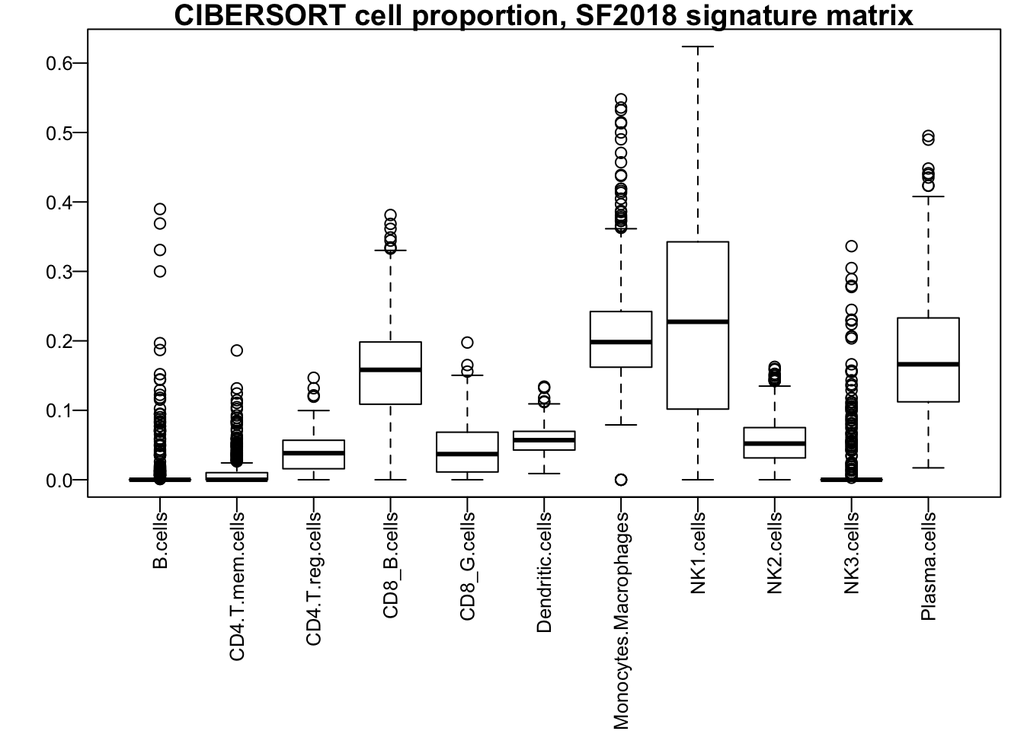

```r
par(mar=c(8,3,1,0.8), mgp=c(1.5,0.5,0), cex.axis=0.8)
boxplot(cibersort_cell_fraction_SF2018[,2:12],las=2, main="CIBERSORT cell proportion, SF2018 signature matrix")
```

Boxplot of cell fraction for each cell type inferred using SF2018_few0 signature matrix in CIBERSORTx

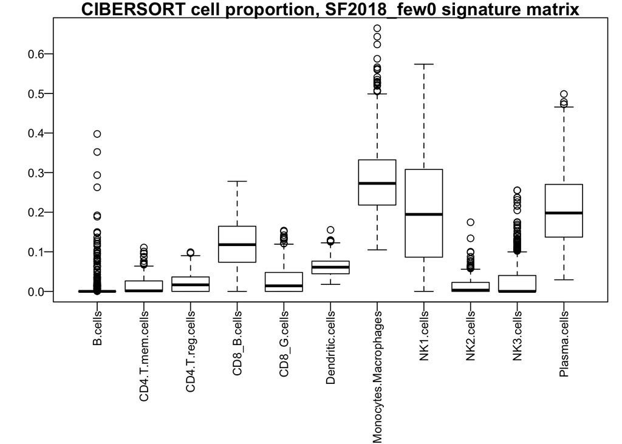

```r
par(mar=c(8,3,1,0.8), mgp=c(1.5,0.5,0), cex.axis=0.8)
boxplot(cibersort_cell_fraction_SF2018_few0[,2:12],las=2, main="CIBERSORT cell proportion, SF2018_few0 signature matrix")
```

Correlation plot compare cell fractions inferred using LM22 signature matrix and SF2018 signature matrix in CIBERSORTx  
- For most of the cell types, we see the fractions inferred using different signature matrix correlated - Fractions of dendritic cell inferred using the 2 types of signature matrices have small correlation - The fractions three types of NK cells also showed some dubious correlation: only the fraction of NK1 is more positively correlated with the fraction of resting NK cells, and they showed some correlation with other cell types.

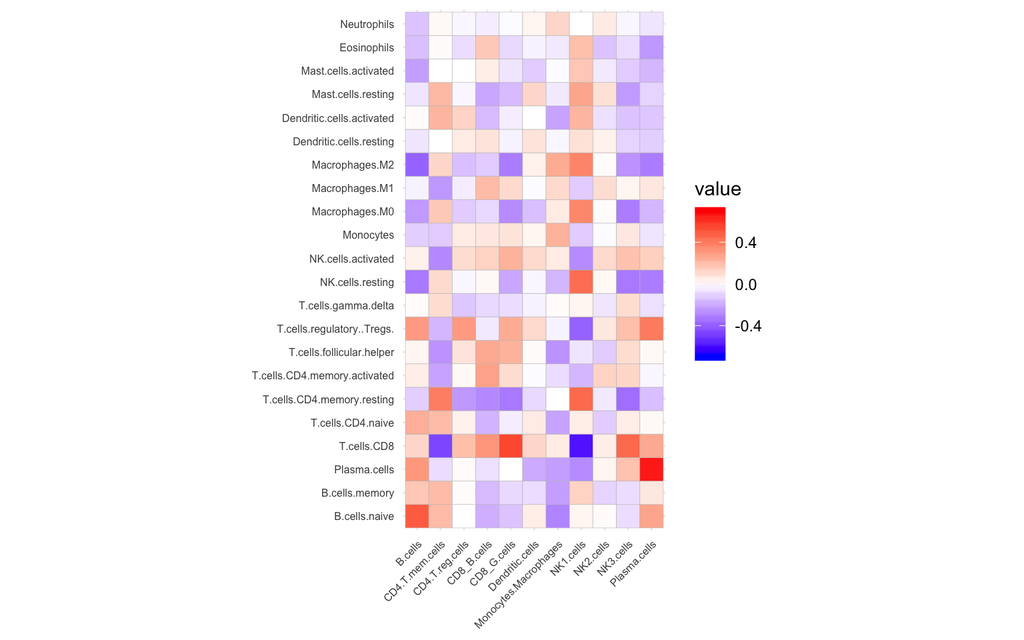

```r
cormat_LM22_SF2018 = matrix(0, nrow = 22, ncol = 11)
colnames(cormat_LM22_SF2018)= colnames(cibersort_cell_fraction_SF2018)[2:12]
rownames(cormat_LM22_SF2018) = colnames(cibersort_cell_fraction_LM22)[2:23]

for (i in 1:22) {
  for (j in 1:11) {
   cormat_LM22_SF2018[i,j] = cor(cibersort_cell_fraction_SF2018[,j+1], cibersort_cell_fraction_LM22[,i+1],method = "spearman")
  }
}

p = ggcorrplot(t(cormat_LM22_SF2018), tl.cex = 6)
p + scale_fill_gradient2(limit = c(-0.7,0.7), low = "blue", high =  "red", mid = "white", midpoint = mean(c(-0.7,0.7)))
```

Correlation plot compare cell fractions inferred using LM22 signature matrix and SF2018_few0 signature matrix in CIBERSORTx  
- The result is in general similar to that above - For some cell types the correlation is weakened here (CD8_B), for some cell type we saw more noticable correlation (dendritic cells)

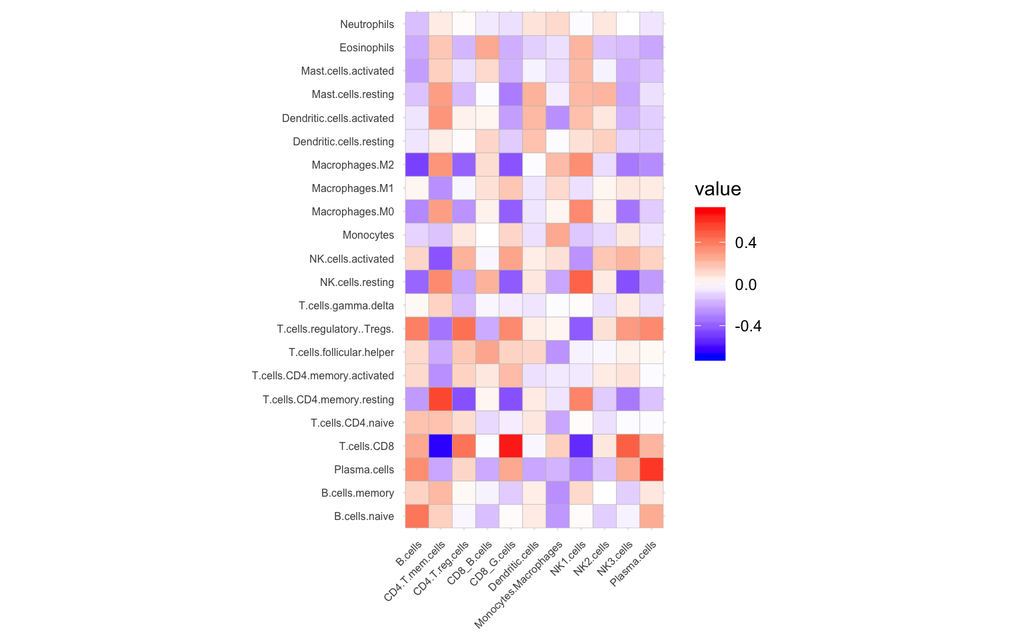

```r
cormat_LM22_SF2018_few0 = matrix(0, nrow = 22, ncol = 11)
colnames(cormat_LM22_SF2018_few0)= colnames(cibersort_cell_fraction_SF2018_few0)[2:12]
rownames(cormat_LM22_SF2018_few0) = colnames(cibersort_cell_fraction_LM22)[2:23]

for (i in 1:22) {
  for (j in 1:11) {
   cormat_LM22_SF2018_few0[i,j] = cor(cibersort_cell_fraction_SF2018_few0[,j+1], cibersort_cell_fraction_LM22[,i+1],method = "spearman")
  }
}

p = ggcorrplot(t(cormat_LM22_SF2018_few0), tl.cex = 6)
p + scale_fill_gradient2(limit = c(-0.7,0.7), low = "blue", high =  "red", mid = "white", midpoint = mean(c(-0.7,0.7)))
```

Correlation plot compare cell fractions inferred using SF2018 signature matrix and SF2018_few0 signature matrix in CIBERSORTx  
- We saw positive correlation for the fraction of the same cell type inferred by the 2 different signature matrix.

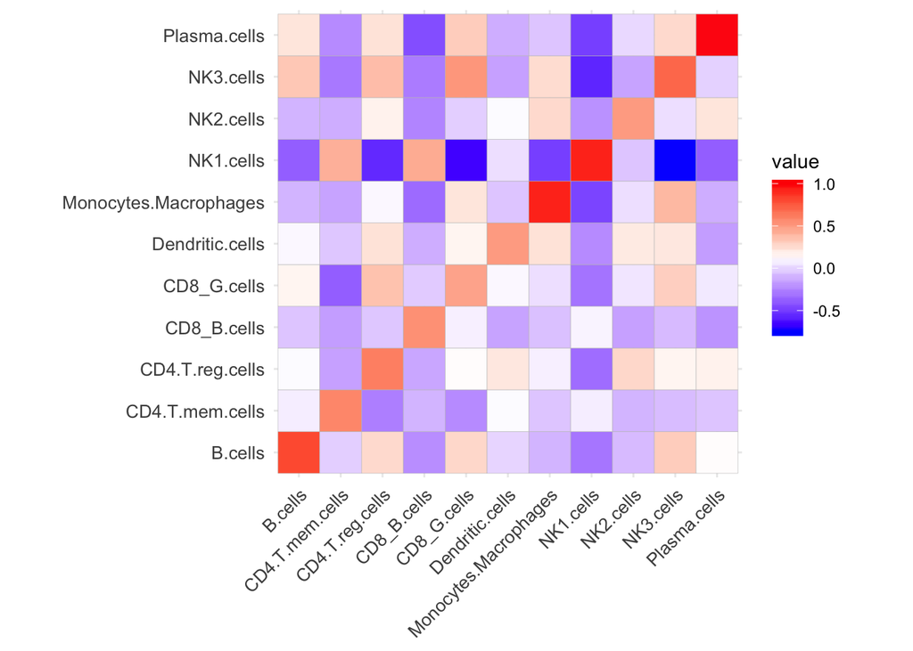

```r
cormat_SF2018andfew0 = matrix(0, nrow = 11, ncol = 11)
colnames(cormat_SF2018andfew0)= colnames(cibersort_cell_fraction_SF2018_few0)[2:12]
rownames(cormat_SF2018andfew0) = colnames(cibersort_cell_fraction_SF2018)[2:12]

for (i in 1:11) {
  for (j in 1:11) {
   cormat_SF2018andfew0[i,j] = cor(cibersort_cell_fraction_SF2018_few0[,j+1], cibersort_cell_fraction_SF2018[,i+1],method = "spearman")
  }
}

p = ggcorrplot(t(cormat_SF2018andfew0), tl.cex = 10)
p + scale_fill_gradient2(limit = c(min(cormat_SF2018andfew0),1), low = "blue", high =  "red", mid = "white", midpoint = mean(c(min(cormat_SF2018andfew0),1)))
```

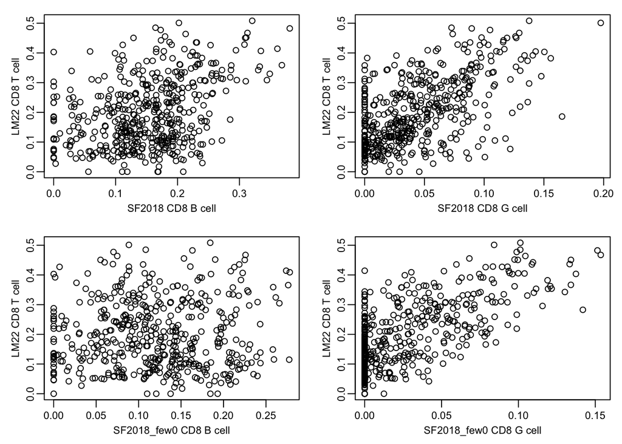

```r
par(mar=c(3,3,1,0.8), mgp=c(1.5,0.5,0), cex.axis=0.85, cex.lab=0.85, cex.main=0.85)
layout(matrix(c(1,2,3,4),nrow=2,ncol = 2,byrow = TRUE))

plot(cibersort_cell_fraction_SF2018$CD8_B.cells, cibersort_cell_fraction_LM22$T.cells.CD8, xlab = "SF2018 CD8 B cell", ylab = "LM22 CD8 T cell")

plot(cibersort_cell_fraction_SF2018$CD8_G.cells, cibersort_cell_fraction_LM22$T.cells.CD8, xlab = "SF2018 CD8 G cell", ylab = "LM22 CD8 T cell")

plot(cibersort_cell_fraction_SF2018_few0$CD8_B.cells, cibersort_cell_fraction_LM22$T.cells.CD8, xlab = "SF2018_few0 CD8 B cell", ylab = "LM22 CD8 T cell")

plot(cibersort_cell_fraction_SF2018_few0$CD8_G.cells, cibersort_cell_fraction_LM22$T.cells.CD8, xlab = "SF2018_few0 CD8 G cell", ylab = "LM22 CD8 T cell")
```

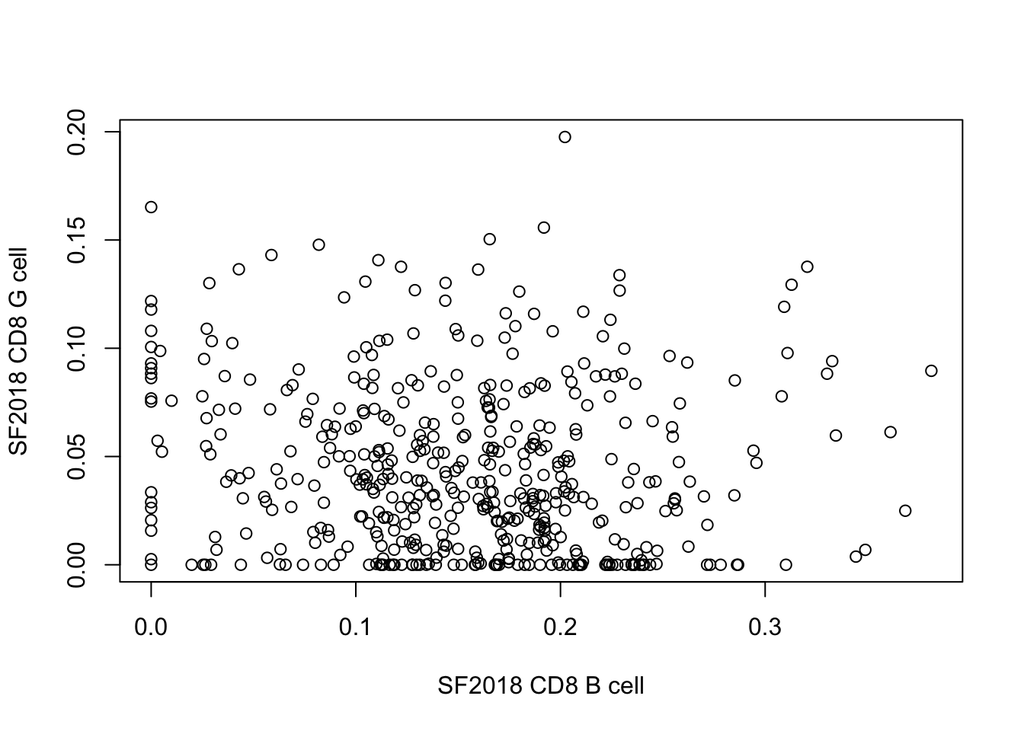

```r
plot(cibersort_cell_fraction_SF2018$CD8_B.cells, cibersort_cell_fraction_SF2018$CD8_G.cells, xlab = "SF2018 CD8 B cell", ylab = "SF2018 CD8 G cell")
```

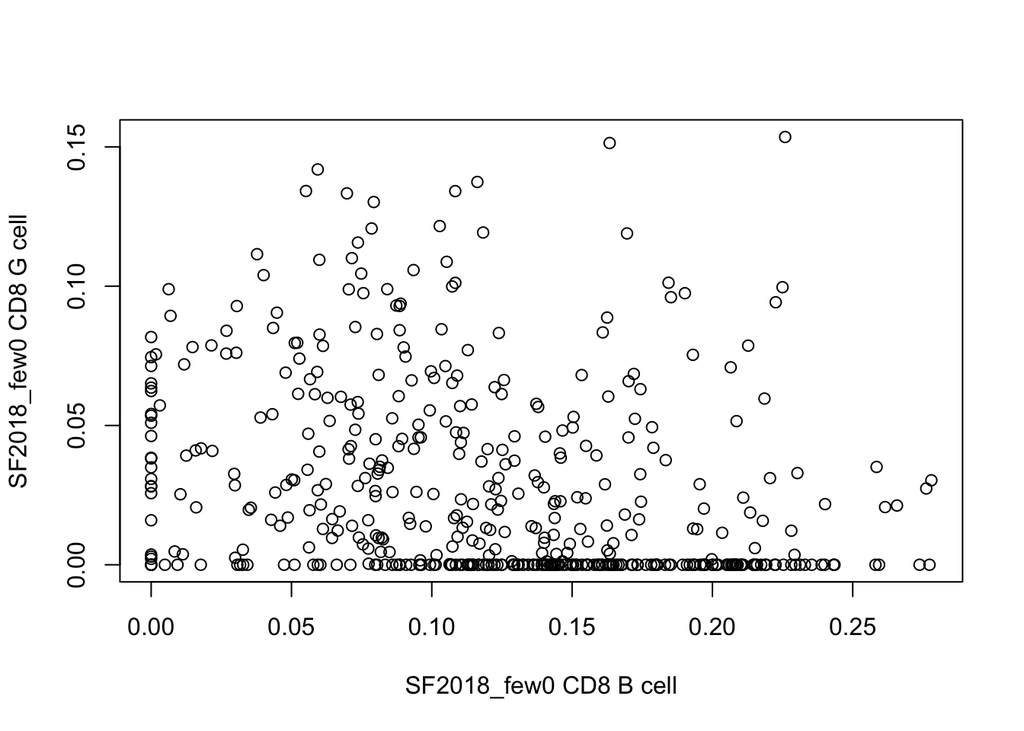

```r
plot(cibersort_cell_fraction_SF2018_few0$CD8_B.cells, cibersort_cell_fraction_SF2018_few0$CD8_G.cells, xlab = "SF2018_few0 CD8 B cell", ylab = "SF2018_few0 CD8 G cell")
```

# Run ICeDT

Got error at this step: likelihood decreased during EM

```r
icedt_output_file =  "SKCM_ICeDT_output.rds"
if (!file.exists(icedt_output_file)) {
  set.seed(34548)
  icedt_output = ICeDT::ICeDT(
    Y = SKCM_TPM,
    Z = signature_matrix,
    tumorPurity = NULL,
    refVar = NULL)
  # save to ICeDT cellular frequency RDS file
  saveRDS(icedt_output, icedt_output_file)
} else {
  icedt_output = readRDS(icedt_output_file)
}
```

```r
gc()
```

```
##           used (Mb) gc trigger (Mb) limit (Mb) max used (Mb)
## Ncells  831679 44.5    1604610 85.7         NA  1227935 65.6
## Vcells 1566019 12.0    8388608 64.0      16384  3042404 23.3
```